# RaceReport

## Fantasy League Scores

Scores for drivers/constructors in the current year's fantasy league, along with manager/team points, values, and statistics. Note: driver and constructor values are taken as the cost to enter the current race and are updated the week before the race.

## Lineup Scores

Max Verstappen takes a dominant win as we head into the final three rounds of the season, with a huge 56 points ahead of nearest challenger Kimi Antonelli with 32 points. He's joined by Mercedes teammate George Russell with 30 points, ahead of Charles Leclerc with 23. Lewis Hamilton rounds out the top five places with 18 points. Gabriel Bortoleto secures the bottom spot this week, tied with Lance Stroll, the pair coming home with -20 points. Alex Albon next with -17 points, behind the two McLarens of Piastri and Norris with -14 and -10 points. Pierre Gasly rounds out the bottom five places with -2 points.

Red Bull take the top step this week with 85 points, ahead of Mercedes with 77 and Ferrari with 48. Their run of form is over though, as McLaren suffer their first loss of points of the season with -34 points. Aston Martin and Kick Sauber are next with -8 points, behind Alpine with 3 points.

With a near-70 point swing in the championship, Max Verstappen takes the lead in the standings with 675 points. Norris is in second with 653 points, ahead of Piastri with 570 points. George Russell holds on to fourth place with 538 points, and Charles Leclerc rounds out the top five with 367 points. Franco Colapinto sits at the bottom of the table with a pair of points, behind Fernando Alonso with 29. Bortoleto next with 33 points, behind Liam Lawson with 47 and Pierre Gasly with 52.

McLaren take a little step back at the top of the table, but they're still comfortably clear with 1571 points. Red Bull are in second with 1108 and Mercedes in third with 1093. Alpine are at the bottom of the table with 147 points, behind Kick Sauber with 263 and Aston Martin with 276.

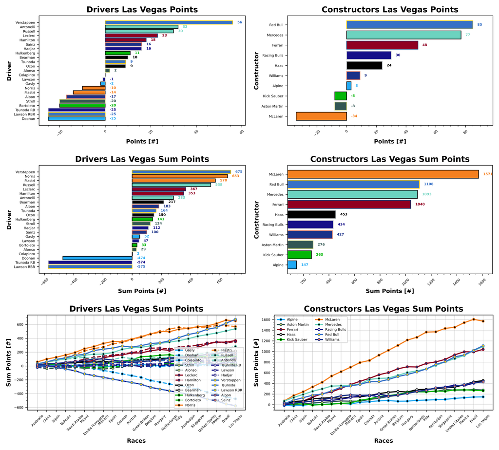

Your most expensive option this week was Lando Norris with a value of 30.4, ahead of Max Verstappen with a value of 29.2. Oscar Piastri is next with a value of 26.0, followed by George Russell with 23.4. Charles Leclerc rounds out the expensive five with 23.3. Franco Colapinto was your cheapest option this week, along with teammate Pierre Gasly, who sit at 4.7. They're behind Fernando Alonso at 5.5, and Isack Hadjar at 5.9. Carlos Sainz next at 6.3, with Liam Lawson and Esteban Ocon rounding out the cheap seats at 6.5.

McLaren were your most expensive option for constructors this week with a 35.6 value, ahead of Ferrari at 31.5 and Red Bull at 30.2. Alpine were your cheapest option at 9.1, behind Kick Sauber at 10.5 and Aston Martin at 11.7.

All values are in Million Dollars.

Driver of the season so far has been George Russell, the Mercedes man maintaining his 100% positive scoring record. Max Verstappen is in second with a 95.45% rate, followed by Esteban Ocon with 90.91%. Franco Colapinto is the worst driver of the season, scoring positively at only 40.91% of the races, behind Bortoleto and Lawson with 59.09%. Gasly and Alonso next, who have scored positively at 63.64% of the races to date.

REd Bull and Mercedes maintain their 100% record this season so far, ahead of McLaren with 95.45%. Williams and Haas next at 90.91%. Kick Sauber are the worst team of the season, coming in at 72.73% positive scoring rate so far, behind Racing Bulls, Aston Martin, and Alpine with 77.27%. Ferrari round out the bottom three with 86.36%.

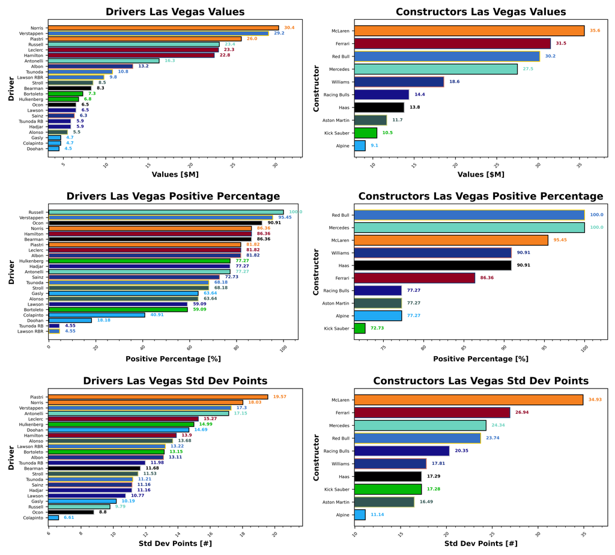

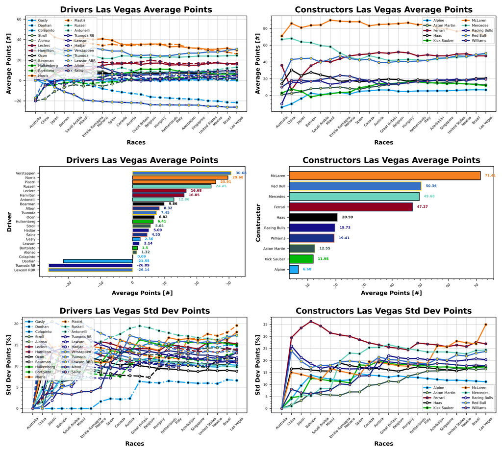

Driver of the week goes to Isack Hadjar with a points per value of 2.71 ppm, ahead of Carlos Sainz with 2.54 ppm. Kimi Antonelli next with a 1.96 ppm, ahead of race winner Verstappen with 1.92 ppm. Nico Hulkenberg rounds out the top five with 1.62 ppm. Worst driver of the week is Gabriel Bortoleto who comes home with a points per value of -2.74 ppm, behind Lance Stroll with -2.35 ppm. Alex Albon next with a -1.29 ppm, behind Oscar Piastri with -0.54 ppm. Pierre Gasly rounds out the bottom five with -0.43 ppm.

Red Bull are your team of the week this week with a points per value of 2.81 ppm, just ahead of Mercedes with 2.8 ppm. Racing Bulls complete the podium with 2.08 ppm. McLaren are your worst team of the week with -0.96 ppm, behind Kick Sauber with -0.76 ppm and Aston Martin with -0.68 ppm.

ppm = points per million Dollars.

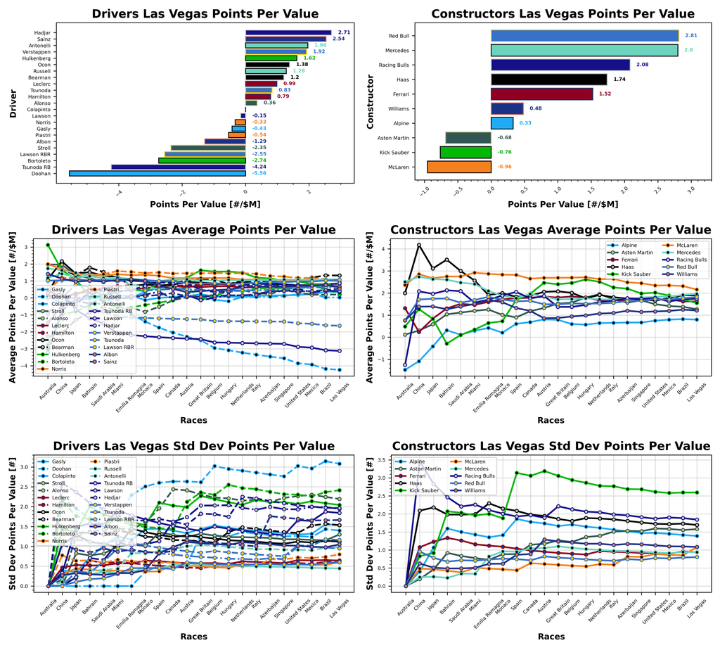

### Manager Scores

Victory in Sin City goes to Phil and BMW FTW who take a huge 300 points haul home with them this week. Behind is Val and No U Turn with 276 points, ahead of Josh and HSBC Jaguar Racing with 230. Sebastian next with Allianz BMW Williams coming in with 214 points. Finn rounds out the top five with Ro@d R@ge and 174 points.

Stuart and Taylormade To Lose just secure a victory in the Golf League this week with -78 points, ahead of Valerie and Perez For World Champion with -75 points. Their other team, Stroll To The 18th is in third place with -68points, ahead of James and Bwoah Schweppes Puma Golf with -62 points. Valerie rounds out the bottom five with What Arrrgh Ya Doohan coming in with -51 points.

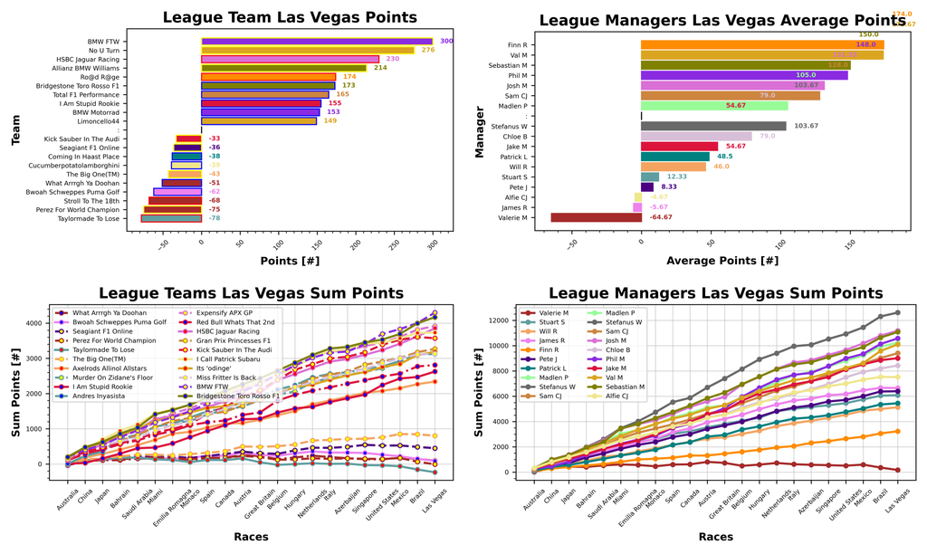

Stefanus and Syahrul are still out front with a score of 4591 points, ahead of Patrick and You Hadjar Chance Racing with 4313 points. Phil and BMW FTW are in third place with 4301 points, ahead of Sebastian and Bridgestone Toro Rosso F1 with 4169 points. Stefanus and Haryanto round out the top five with 4123 points.

Stuart and Taylormade To Lose are leading the way in the Golf League with a score of -234 points. Valerie is in second and third with Perez For World Champion and Stroll To The 18th with -9 and 79 points. James is in fourth with Bwoah Schweppes Puma Golf sitting on 87 points. Valeria and What Arrrgh Ya Doohan round out the bottom five with 96 points.

Biggest winners of the week are Phil and Finn with BMW Motorrad and Ro@d R@ge both jumping 7 places in the standings. Biggest loses this week are Chloe and Stuart with Miss Fritter Is Back and Andres Inyasista both dropping 5 places.

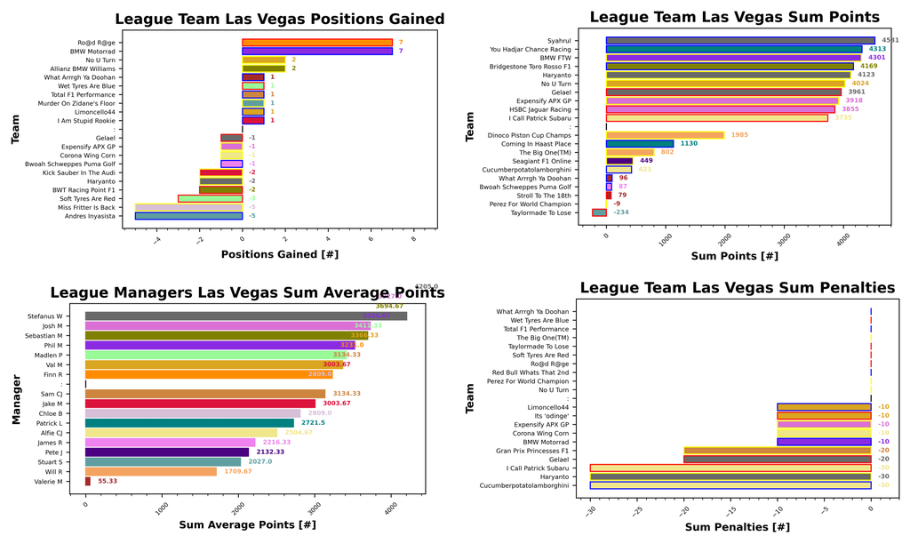

Isack Hadjar is your most popular driver this week with 32 token selections under the lights. He's followed by Carlos Sainz with 22 and Fernando Alonso with 18 selections. Then we have Nico Hulkenberg with 16 selections and Oliver Bearman with 15. Your least selected driver was Lewis Hamilton, with only 2 of you choosing him for your teams. Then we have Lance Stroll with 3 and Charles Leclerc with 5. Esteban Ocon next with 8 selections, with Kimi Antonelli and Liam Lawson rounding out the bottom five with 9 selections each.

McLaren and Kick Sauber were your most selected teams this week, both of them making 16 selections in Vegas. Then we have Racing Bulls with 11 selections, Mercedes and Haas with 10, Ferrari with 9, and the other teams all making it 6 a piece.

Oscar Piastri remains the most popular driver to DRS Boost, the Aussie making it 10 selections this week, ahead of Verstappen with 9 and Norris with 8. Only 2 tokens used this week and both of them were wildcards.

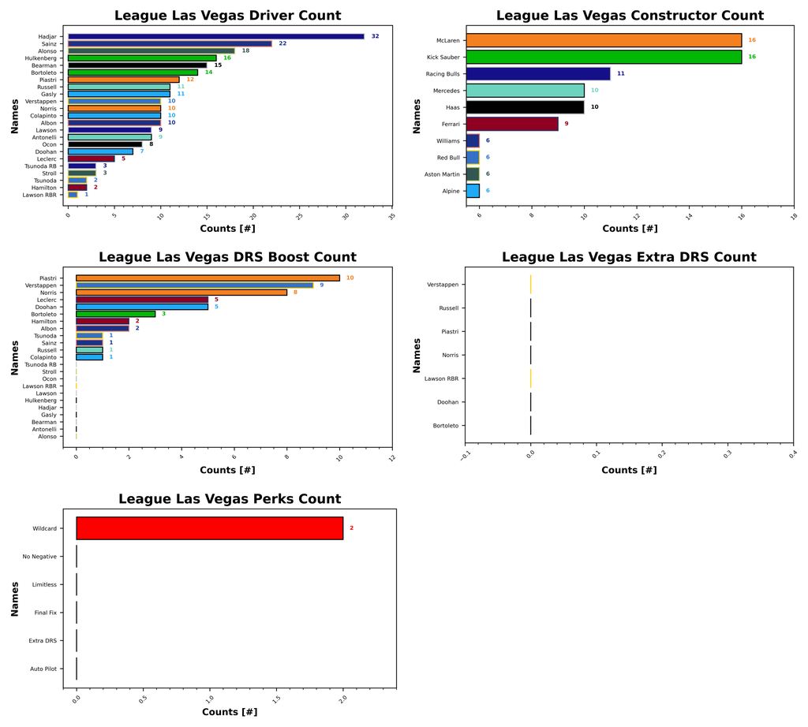

## Prizes

### Championship

| Prize Name | Prize Value | Terms | Manager | Team | Score |
| --- | --- | --- | --- | --- | --- |
|  | (%) |  |  |  |  |
| Champion of the World | 20 | Awarded to the top scorer in the league at the end of the season |  |  |  |
| If You're Not First, You're Last | 10 | Awarded to the second place scorer in the league at the end of the season |  |  |  |
| Alpine Podium | 5 | Awarded to the third place scorer in the league at the end of the season |  |  |  |
| Above Par | 20 | Awarded to the lowest scorer in the league at the end of the season, commonly referred to as the Golf League |  |  |  |

### Achievements

| Prize Name | Prize Value | Terms | Managers | Teams | Scores | Details |
| --- | --- | --- | --- | --- | --- | --- |
|  | (%) |  |  |  |  |  |
| Cost Cappen | 5 | Highest average points per value at the end of the season |  |  |  |  |
| Sprint King | 5 | Highest score across the sprint races (China, Miami, Belgium, United States, Brazil, Qatar) | Stefanus Stefanus Josh | Haryanto Syahrul HSBC Jaguar Racing | 1590 1586 1476 |  |
| Flavio Controls Every Millimeter | 5 | Manager wide substitution count, highest wins |  |  |  |  |
| The Triple Header | 5 | Highest score across the triple header races (Japan, Bahrain, Saudi Arabia, Emilia Romagna, Monaco, Spain, Las Vegas, Qatar, Abu Dhabi) |  |  |  |  |
| I Forgot I Was Taking Part | 5 | Highest score in the first part of the season | Stefanus Stefanus Sebastian | Syahrul Haryanto Bridgestone Toro Rosso F1 | 3128 2924 2874 |  |
| Zak's Master Plan | 5 | Lowest score in the second half of the season |  |  |  |  |
| Mega Driver | 5 | Highest Extra DRS token score |  |  |  |  |
| The Continental | 5 | Highest score across all 5 continents, Mexico classed as South America for inclusion only (Australia, Canada, Great Britain, Azerbaijan, Mexico) | Finn Stefanus Sebastian | Ro@d R@ge Syahrul Bridgestone Toro Rosso F1 | 767 760 758 |  |

### Spot Prizes

| Prize Name | Prize Value | Terms | Manager | Team | Score |
| --- | --- | --- | --- | --- | --- |
|  | (%) |  |  |  |  |
| The Ring | 1 | Highest score at the Austrian Grand Prix | Stefanus | Syahrul | 308 |
| Bottas Bowling | 1 | Highest score at the Hungarian Grand Prix | Stefanus | Haryanto | 301 |
| Daniel's Broken Hand | 1 | Lowest score at the Netherlands Grand Prix | Stuart | Taylormade To Lose | 22 |
| The Tifosi | 1 | Lowest score at the Italian Grand Prix | Valeria | Stroll To The 18th | -49 |
| Go For The Gap | 1 | Lowest score at the Singapore Grand Prix | Stuart | Taylormade To Lose | -41 |

## F1 Predict

Phil takes the victory this week with a score of 101, a 57% accuracy. Val secures second place with 54 points, and a 37% accuracy, ahead of Josh with 48 points and a 27% accuracy. All others scored 0.

With that, Phil holds onto the top step with 1417 points. Val is in second place with 1127 ahead of Stuart in third with 1126. Josh is in fourth with 1047, and Pierce is in fifth with 248, ahead of Matty with 95 points.

## Next Up

Next up we have the penultimate round - Qatar. Will Verstappen's momentum stick with him? Can he take the fight to Mclaren.